# **Résultats du sondage** : Etat des lieux du fonctionnement du Boucan de Paillettes (en 2025)

Auteur·rice

Rédaction du sondage : commission horizontalité Interprétation des résultats : commission horizontalité Analyse des données : Suzanne/Suzee

[figure not shown]

# 1 to do

- misejour / vérif thèmes avec nouvelles réponses
- changement couleurs graphiques

# 2 Contexte

Ce sondage anonyme vise à faire l’état des lieux du fonctionnement du Boucan : vos ressentis et idées d’améliorations, il est purement informatif.

Ce sondage a été rédigé par la commision horizontalité du Boucan des Paillettes, après vote en plénière. Le contenu du sondage a été validé en plénière par les membres de l’association.

La commission horizontalité a été créée le 27/08/2025 en plénière afin d’animer un travail pour améliorer le fonctionnement du Boucan.

# 3 Science ouverte et accessibilité

Le code (script R) permettant l’analyses des données est disponible [sur GitHub ici](https://github.com/SuzanneBonamour/sondage_boucan/tree/main).

Les données d’origine ne sont pas rendues accessible afin de respecter l’anonymat des répondant.es.

# 4 Nombre de réponses

# 5 Etat des lieux

29 questions ont pour buts d’établir un état des lieux du fonctionnement de l’association et du bien-être des adhérents et bénévoles.

## 5.1 Depuis combien de temps avez-vous rejoint le Boucan ?

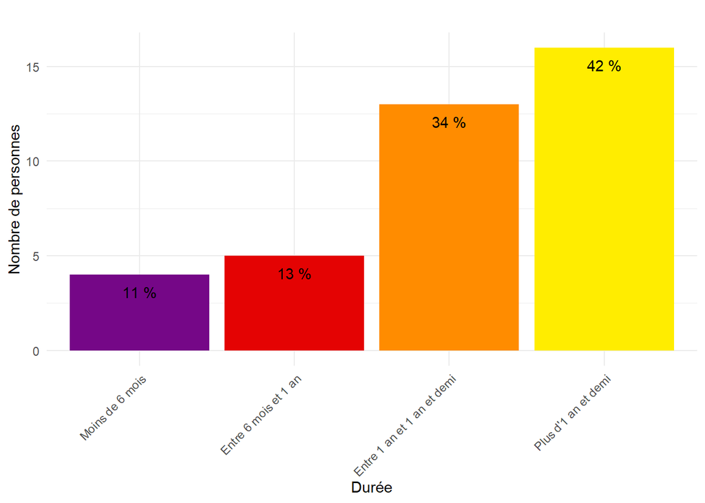

## 5.2 Dans combien de commissions êtes-vous inscrit.e ?

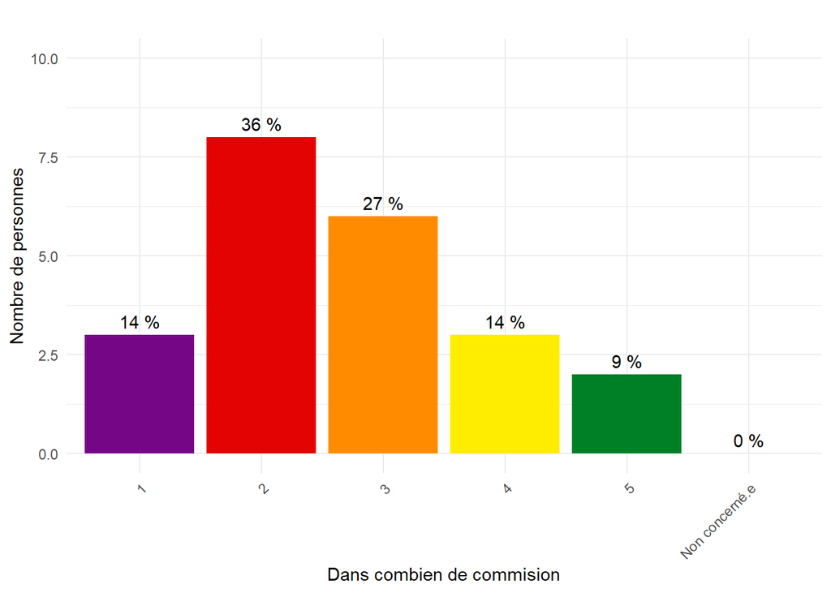

## 5.3 Dans combien de commissions êtes-vous réellement actif.ve ?

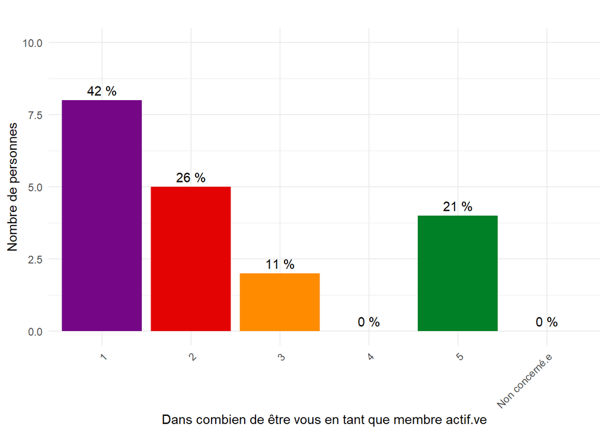

## 5.4 A quelle fréquence venez-vous aux réunions plénières ?

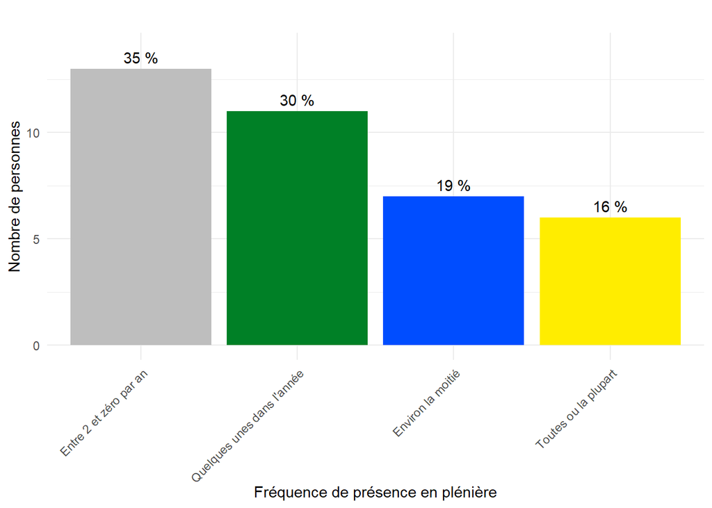

## 5.5 Votre investissement a-t-il évolué depuis votre adhésion ? Pourquoi ?

29 commentaires ont été écrits pour cette rubrique.

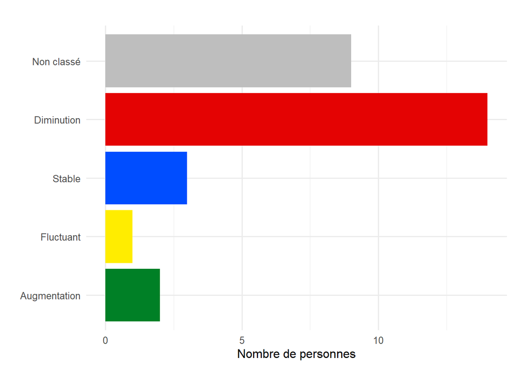

Pourquoi l’investissement diminue ?

| Thème | Mots-clés associés |
| --- | --- |
| Fatigue / burn-out | fatigu, épuis, burn, désinvest, manque d’énergie |
| Commissions peu actives | peu actives, ne se réunit plus |
| Manque de disponibilité | temps, agenda, activité, soir, disponibil, municipal, possibilité de venir |
| Problèmes organisationnels | autonomie, long, compliqué |
| Tensions relationnelles | tension, conflit, relation, interperson, contrôle |
| Charge collective insuffisante | plus assez de personnes, charge, porter, seul |

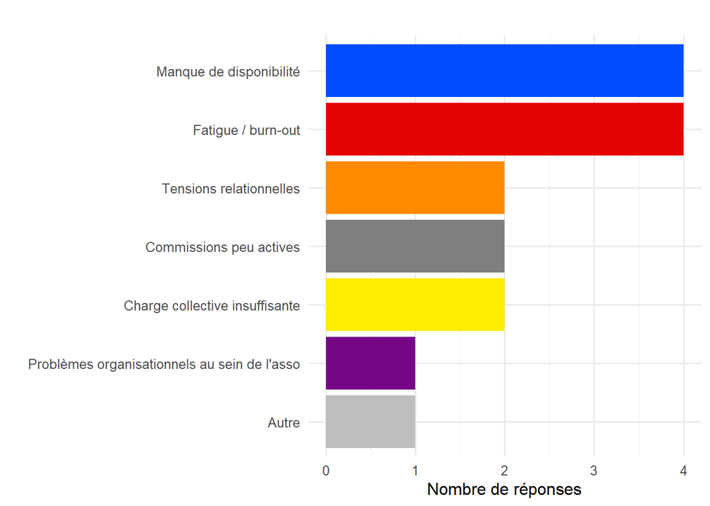

Extraits choisis :

- *“Tensions interpersonnelles qui éclaboussent même les personnes qui n’y sont pas mêlées”*
- *“Le manque de liberté d’action et d’autonomie me freine”*
- *“Il y a un besoin de contrôle qui fait que tout est si long et compliqué”*

## 5.6 Avez-vous rencontré des situations qui vous ont posé problème dans l’association ?

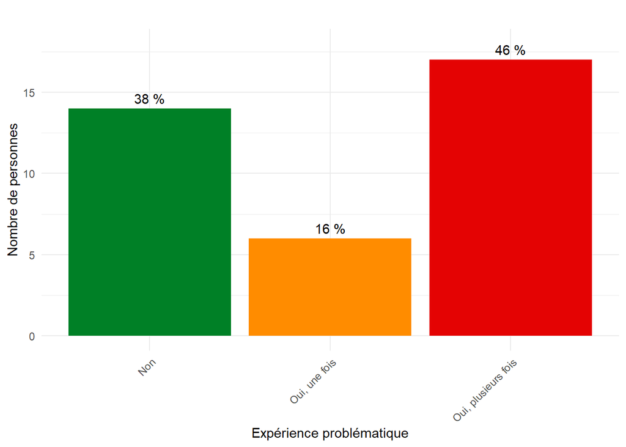

### 5.6.1 Commentaires

22 commentaires ont été écrits pour cette rubrique.

Thèmes :

| Thème | Mots-clés associés |
| --- | --- |
| Conflit relationnel | agressif, houleux, conflit, débat, tension, affect, interpersonnel, irrespect, altercation, ordre, sec |
| Manipulation | gaslighting |
| Inclusivité / écoute | écouté, légitime, inclusif, activant, trans, blanche, effacé, cis |
| Gouvernance | dirigiste, transparence, conseil, paralysé, collégial, descendant, employé, responsable |
| Manque de connaissance / expérience | comprendre, culture, expérience |
| Commentaire positif | table |
| Surcharge de travail | épuisement |

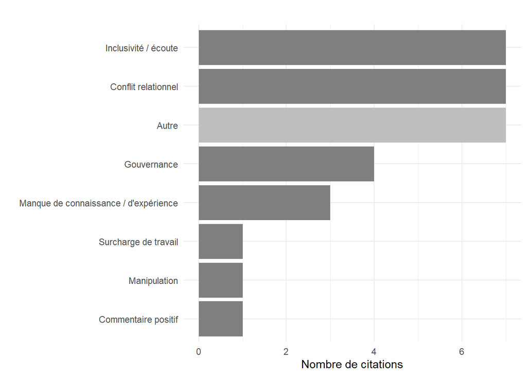

Extraits choisis :

- *“Il y a eu un debat sur le tour de pronoms que j’ai trouvé très activant et irrespectueux des personnes trans”*
- *“La vibe générale du Boucan comme un espace plutot cis et blanc m’ont donné beaucoup moins envie de m’investir”*

## 5.7 Qu’est-ce que vous apporte le Boucan personnellement ?

32 commentaires ont été écrits pour cette rubrique.

| Thème | Mots-clés associés |
| --- | --- |
| Communauté / appartenance | communauté, entre personnes, espace queer, espace, collectivement |
| Soutien / bien-être | bien-être, rassurant, réconfort, soutien, espoir, réponse, joyeuse |
| Engagement militant | milit, droits, lutter, fascisme, cause, pas de droite, intersectionnel, défense, valeur |
| Rencontres / sociabilité | rencontre, convivial, sociabilis, ami, moment |
| Activités / événements | événement, festif |
| Implication / participation | impliquer, investi, contribuer, adhésion, agir, action, projet, participer |
| Existence de l’association en tant que telle | existe, présence |

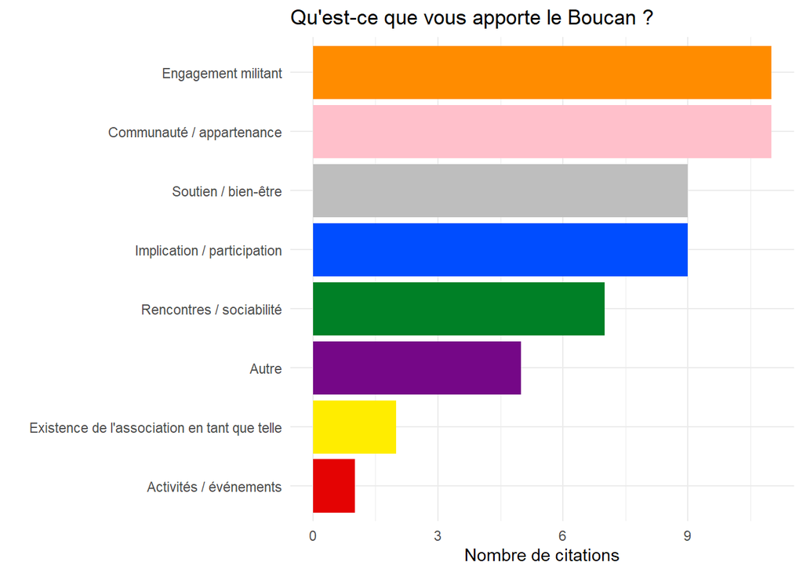

## 5.8 Globalement, comment vous sentez-vous au sein de l’association ?

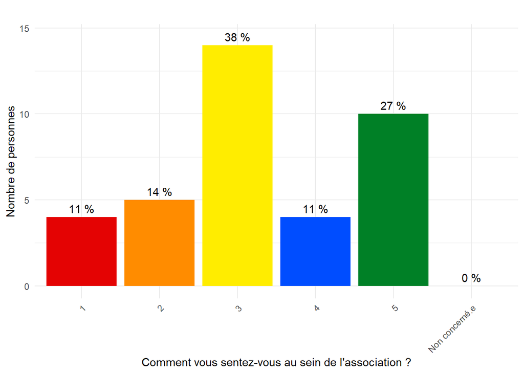

## 5.9 Vous sentez-vous libre d’exprimer vos opinions ?

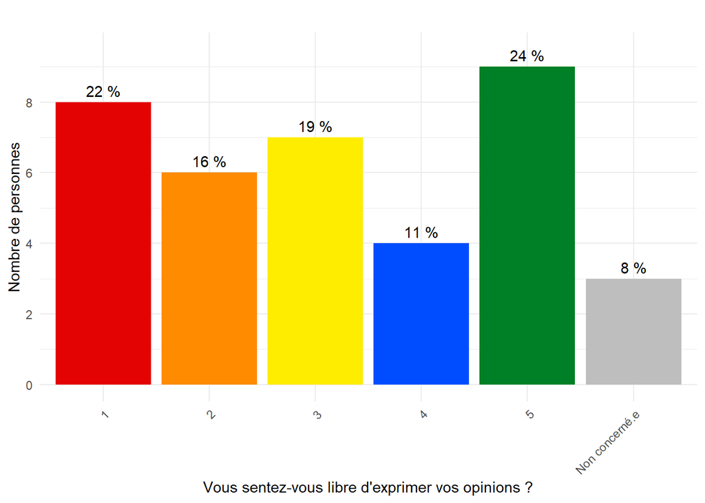

## 5.10 Vous sentez-vous écouté.e au Boucan ?

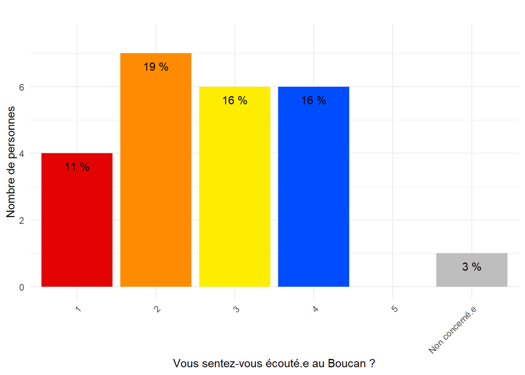

## 5.11 Vous sentez-vous facilement inclus.e au Boucan ?

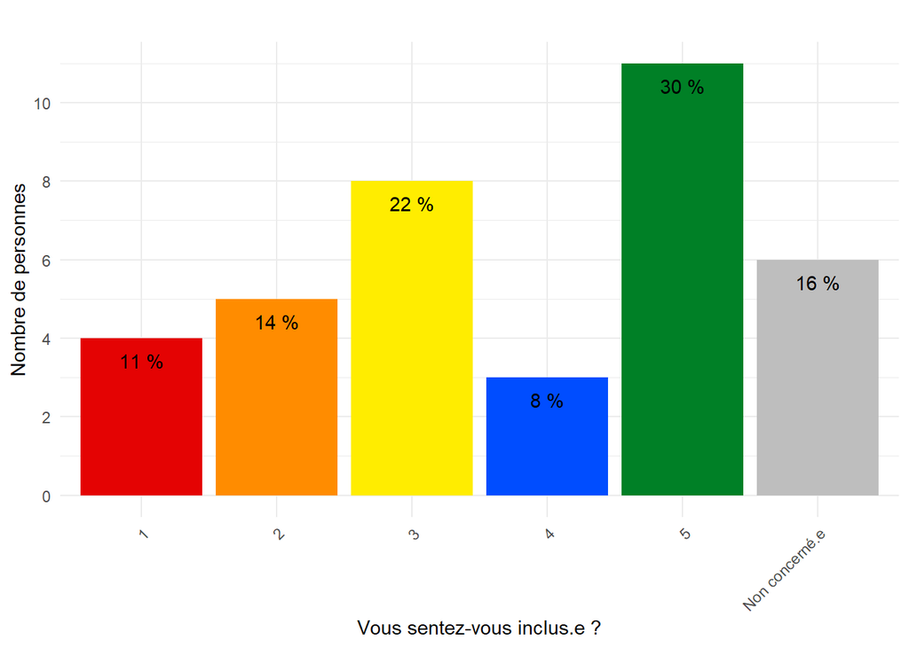

## 5.12 Avez-vous le sentiment d’avoir des interactions globalement bienveillantes ?

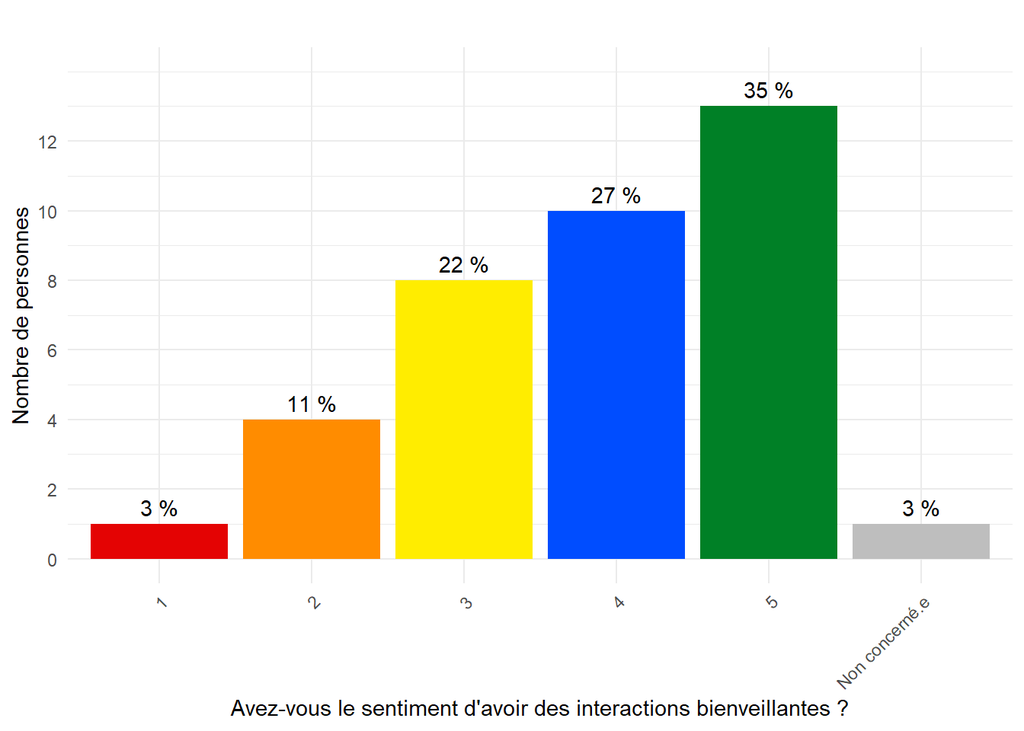

## 5.13 Avez-vous des choses à ajouter sur votre bien-être au Boucan ?

15 commentaires ont été écrits pour cette rubrique.

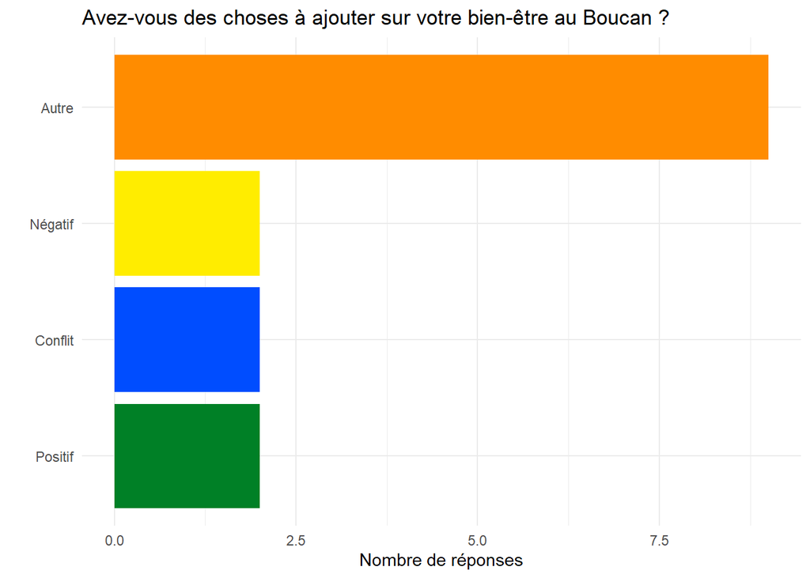

## 5.14 Comment avez-vous trouvé l’accueil au Boucan ?

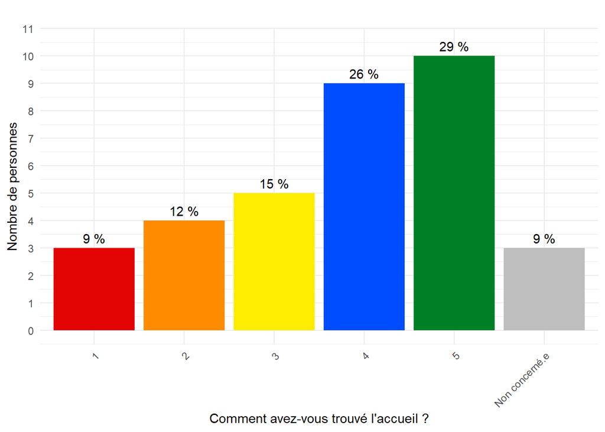

### 5.14.1 Commentaires

10 commentaires ont été écrits pour cette rubrique.

| Thème | Mots-clés associés |
| --- | --- |
| Procédure d’accueil absente | accueil, livret |
| Compréhension de l’organisation | comprendre, fonctionnement, organisation, fonctionner |
| Isolement des nouvelles personnes | seul, isolé, difficile, compliqué, arrivée, nouveau, intégration, impersonnel, relation, contact, personne, rencontré |
| Accueil positif | bon accueil, humain, bien, positif |

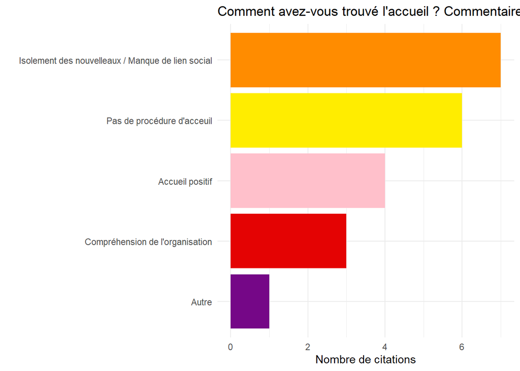

Extraits choisis :

- *“Il n’y a pas de moments d’accueil”*
- *“Il n’a pas de livret d’accueil”*
- *“Vous pourriez peut-être aller vers les nouveaux membres”*
- *“C’est assez impersonnel comme relation”*

## 5.15 Avez-vous une connaissance suffisante du fonctionnement du Boucan pour pouvoir facilement vous y impliquer, prendre des décisions, des responsabilités ?

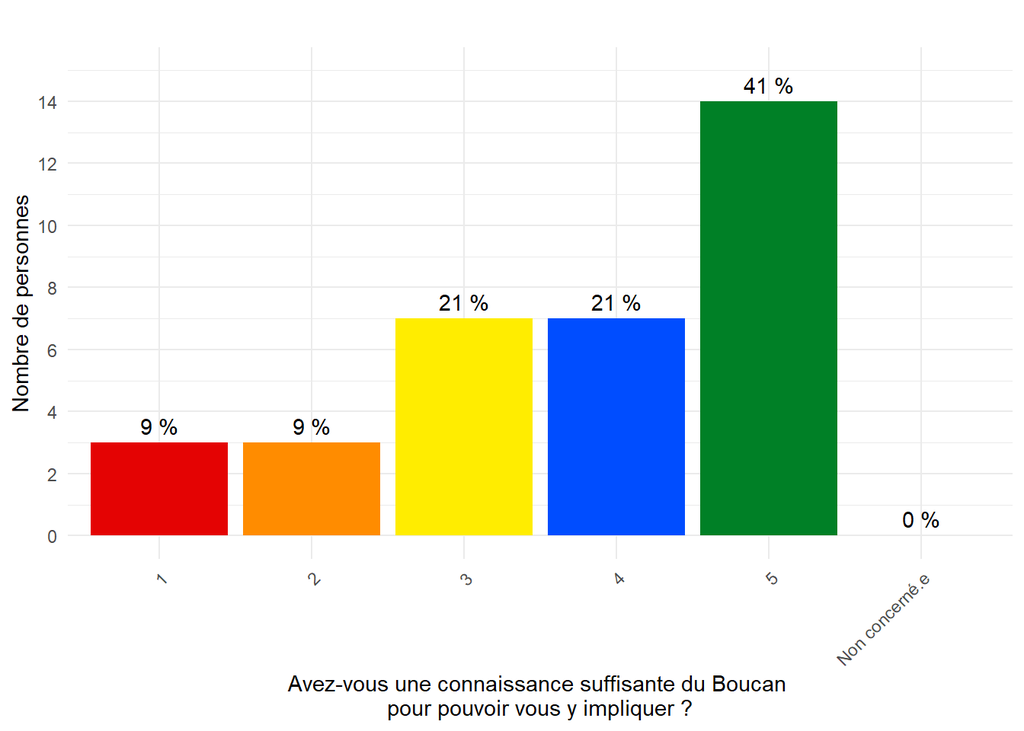

### 5.15.1 Commentaires

11 commentaires ont été écrits pour cette rubrique.

| Thème | Mots-clés associés |
| --- | --- |
| Compréhension du fonctionnement OK | comprendre, clair, comprends, compréhension, acquis, fonctionnement |
| Manque de clarté des rôles | rôle, responsabilité, implication, s’impliquer |
| Manque de clarté fonctionnement CC | conseil, collégial |
| Manque de connaissance | non, lacune, pas très clair, manque, doute |
| Apprentissage en cours | former, formation, documents, accueil, plénière |
| Manque de légitimité | légitime, queer, responsabilités, ne me sens pas |
| Capacité d’implication identifiée | saurais quoi faire, impliquer, possible, acquis |

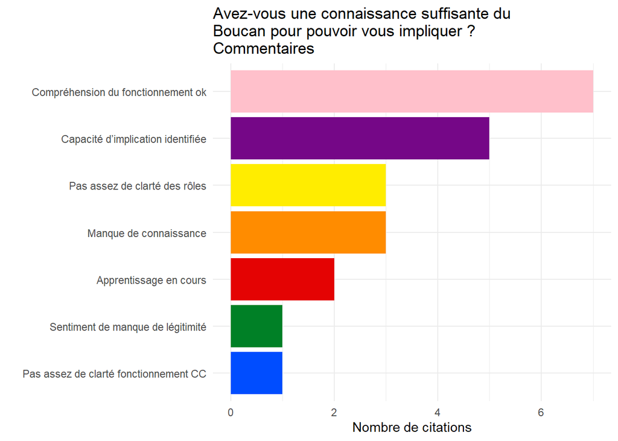

Extrait choisi :

- *“N’étant pas queer, je ne me sens pas légitime pour prendre des responsabilités. (Mais) Cela ne gêne pas l’implication”*

## 5.16 Trouvez-vous les réunions plénières fonctionnelles et efficaces ?

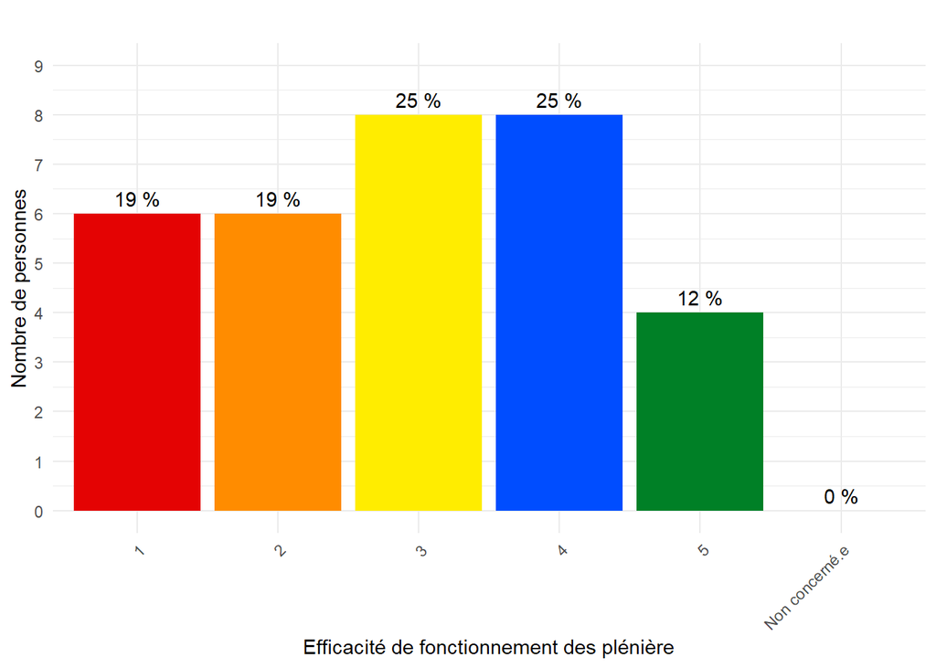

### 5.16.1 Commentaires

13 commentaires ont été écrits pour cette rubrique.

| Thème | Mots-clés associés |
| --- | --- |
| Rôle des plénières (gouvernance) | gouvernance, décision, réflexion, expression |
| Problèmes de vote / démocratie interne | vote, élire, anonym |
| Fatigue / lourdeur des plénières | longues, ennuyeuses, saturantes |
| Problèmes d’organisation / timing | déborder, créneau, temps |
| Accessibilité et inclusion | neuro, care, repos, accessibilité |

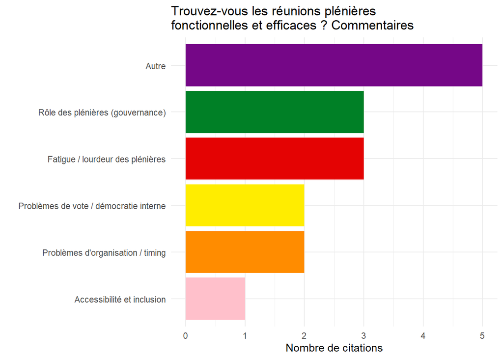

Extraits choisis :

- *“C’est très bien les plénières comme outils de gouvernance, lieu d’expression, de réflexion et de prise de décision”*
- *“Les améliorations récentes sont chouettes (parole uniquement aux commissions présentes, une personne garante du temps”*
- *“Le système de vote pour élire les personnes au CC n’est pas fonctionnel, car pas anonymes, sur une seule liste, pas sur chaque personne en particulier… donc très difficile de”s’opposer à l’élection d’une personne si besoin”*
- *“Très saturantes pour les personnes neuroA”*
- *“Manque de culture du care”*
- *“Il faudrait essayer de les coupler avec une réunion de”“travail”” sur un thème ( exemples: militantisme, culture, solidarité, santé…etc) ou réunion de travail d’une commission”*
- *“Horriblement longues et ennuyeuses”*
- *“Tout y est décidé alors que pleins de gens ne peuvent pas y aller”*

## 5.17 Trouvez-vous les commissions globalement fonctionnelles et efficaces ?

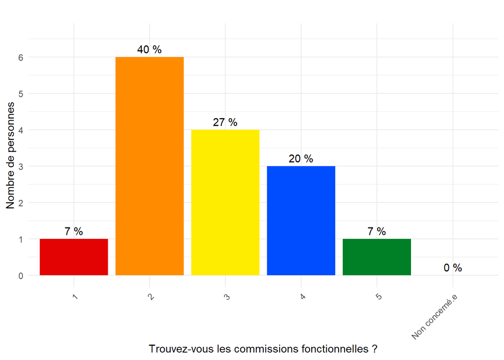

### 5.17.1 Commentaires

13 commentaires ont été écrits pour cette rubrique.

| Thème | Mots-clés associés |
| --- | --- |
| Répartition des ressources / taille des commissions | trop de commission, trop de personne, dilu |
| Manque d’engagement | investir, investissement, bénévole, s’investir, suivre, intérêt sans forcément |
| Manque de clarté / complexité | complexe, compliqu, pas quel bout, fonctionnement |
| Flou des rôles et responsabilités | rôle, référent, conseil collégial, interaction |
| Problèmes de communication sur Telegram | telegram, échanges, communication |

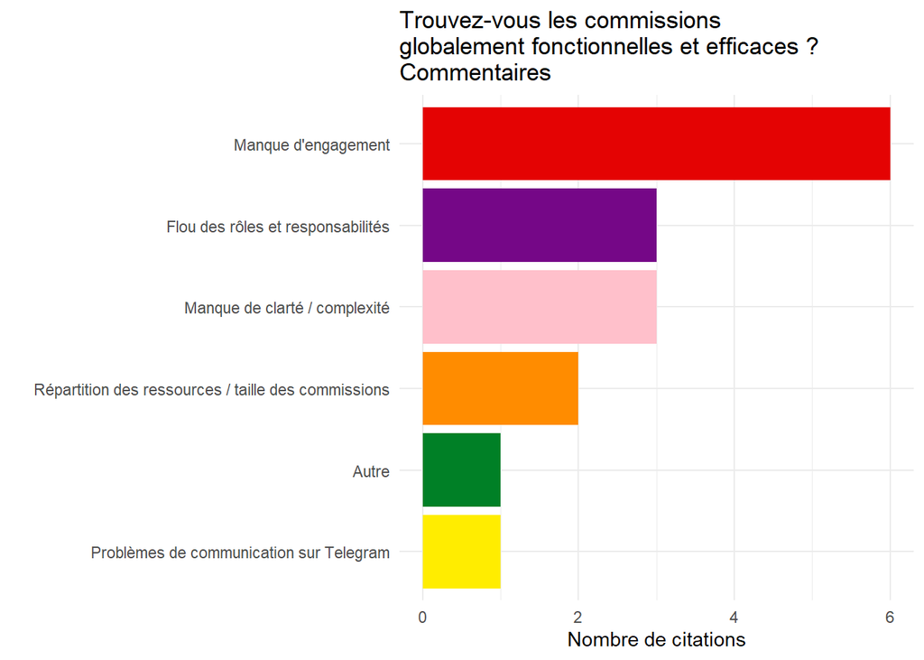

Extraits choisis :

- *“Trop de commission, ou trop de personne par commission, donc les forces vives sont diluées”*
- *“Indiquer si on sera bénévole (rôle actif) ou simplement là pour être tenu au courant de ce qui se passe dans la commission (rôle passif)”*

## 5.18 Pour les commissions : trouvez-vous fonctionnel le lien avec le Conseil Collégial et les réunions plénières ?

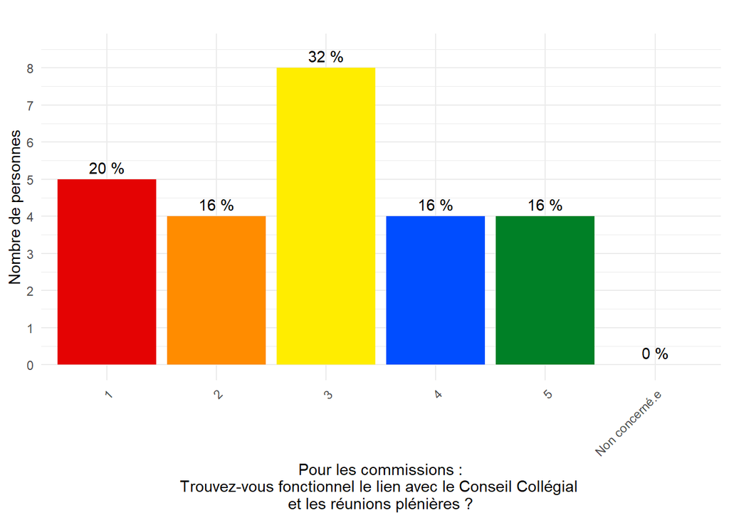

## 5.19 Pour les commissions : trouvez-vous fonctionnel le rôle attribué aux référent.e.s de commissions ?

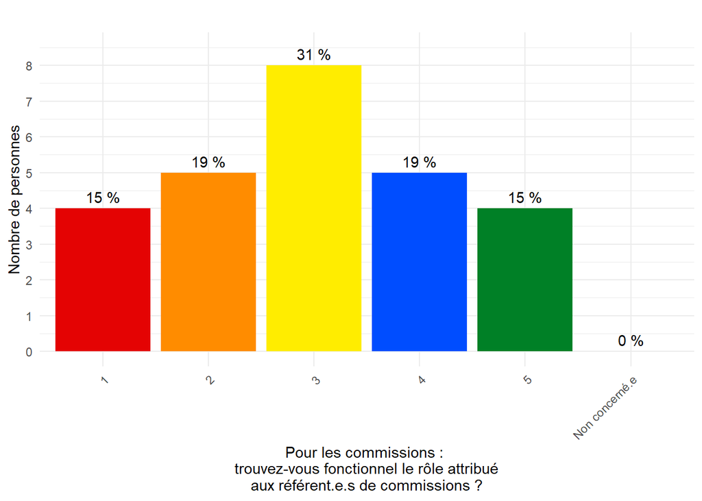

## 5.20 Pour les commissions : trouvez-vous fonctionnelle l’organisation au sein des commissions ?

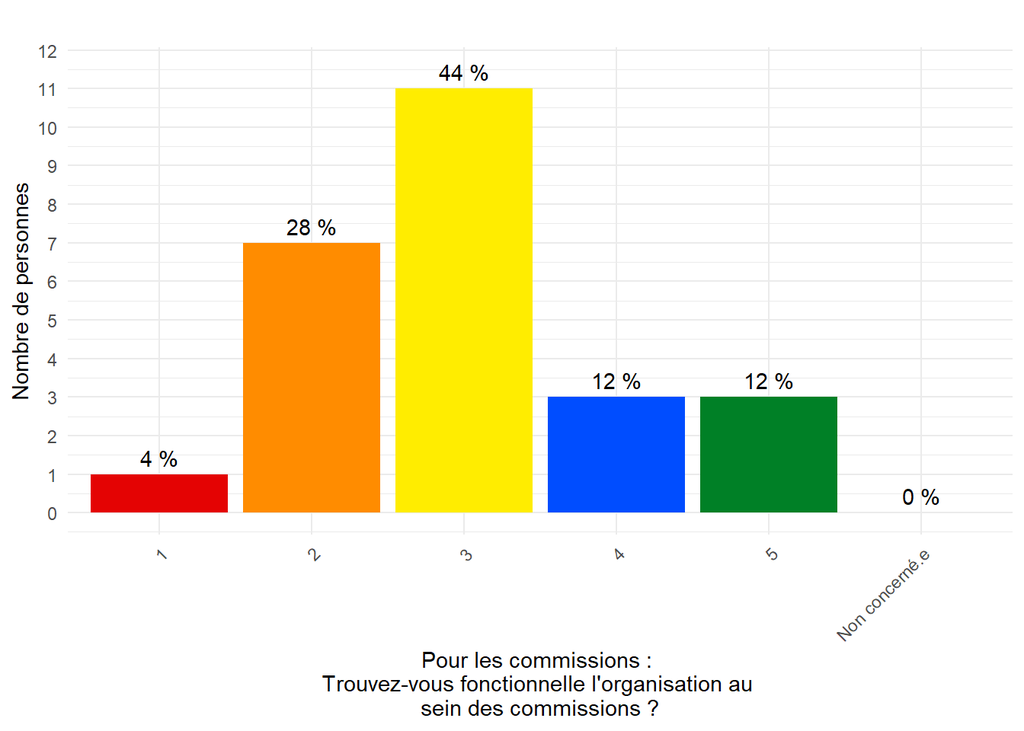

### 5.20.1 Commentaires

7 commentaires ont été écrits pour cette rubrique.

| Thème | Mots-clés associés |
| --- | --- |
| Commissions inactives / peu productives | sommeil, inactive, n’aboutissent, rien |
| Manque de leadership | lead, prendre en main, personne ne le fait |
| Fonctionnement hétérogène selon les commissions | dépend, certaines, d’autres |
| Manque de recul | recul, juger |

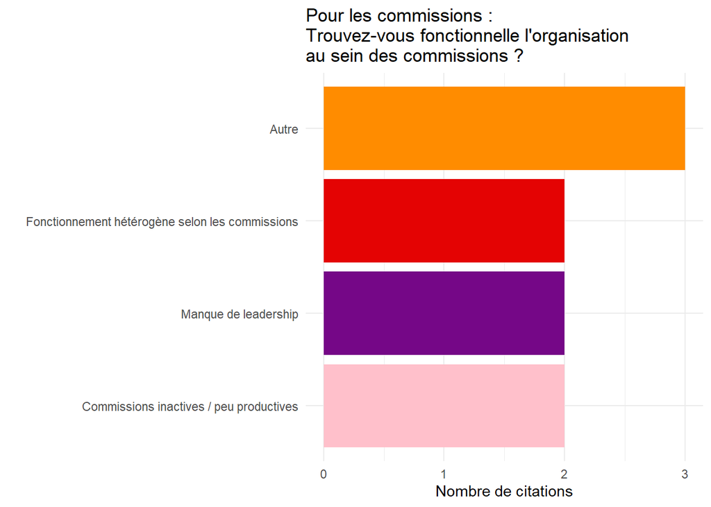

Extraits choisis :

- *“Cela dépends des commissions, globalement, je trouve que lorsqu’une personne prends le lead, tout en faisant valider ou tenant au courant pour concertation les personnes dans la commission ça marche bien”*
- *“si on ne prend pas les choses en main, personne ne le fait”*

## 5.21 Pour les commissions : avez-vous une connaissance suffisante d’à quel point les personnes présentes souhaitent s’investir ?

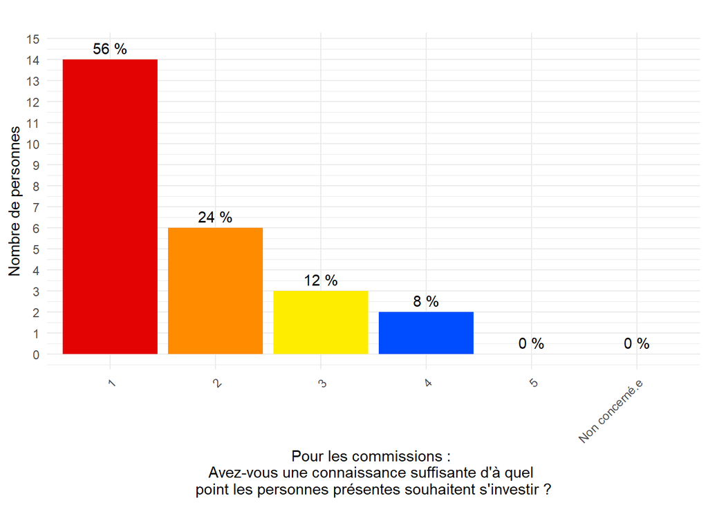

## 5.22 Avez-vous l’impression que les prises de décision sont suffisamment transparentes ?

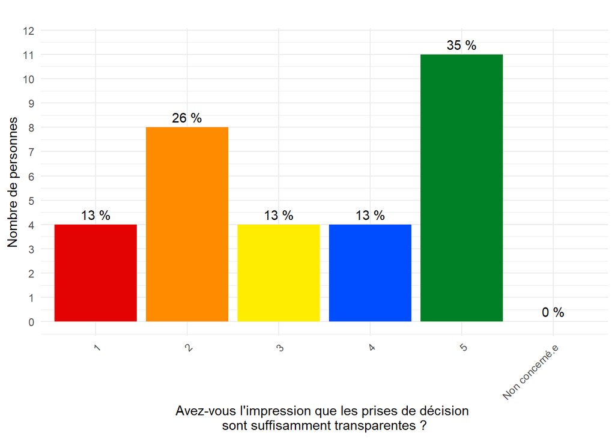

## 5.23 Avez-vous l’impression que la gestion de l’argent est suffisamment transparente ?

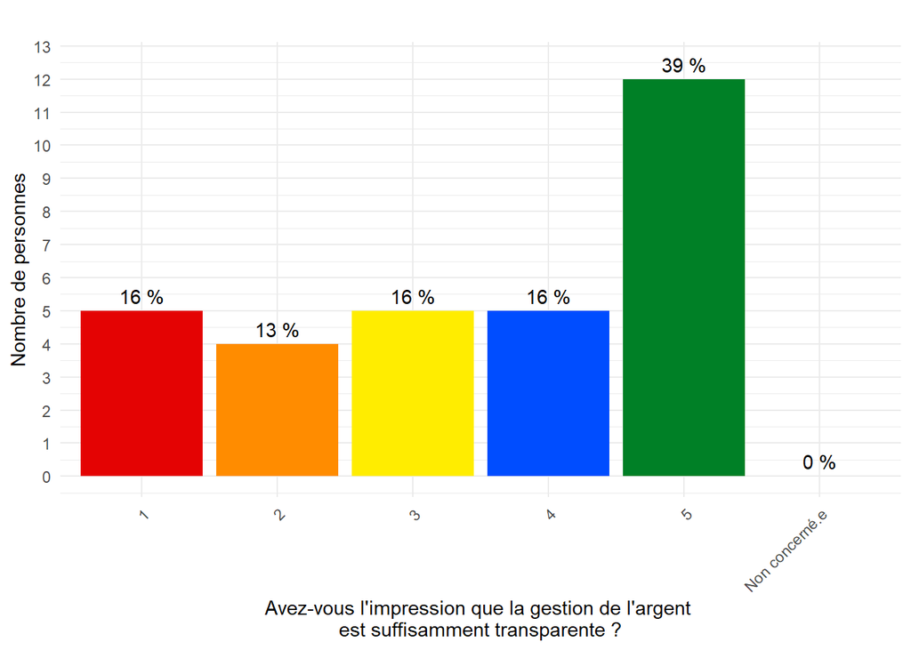

## 5.24 Avez-vous le sentiment que la répartition du pouvoir et des responsabilités est équilibrée ?

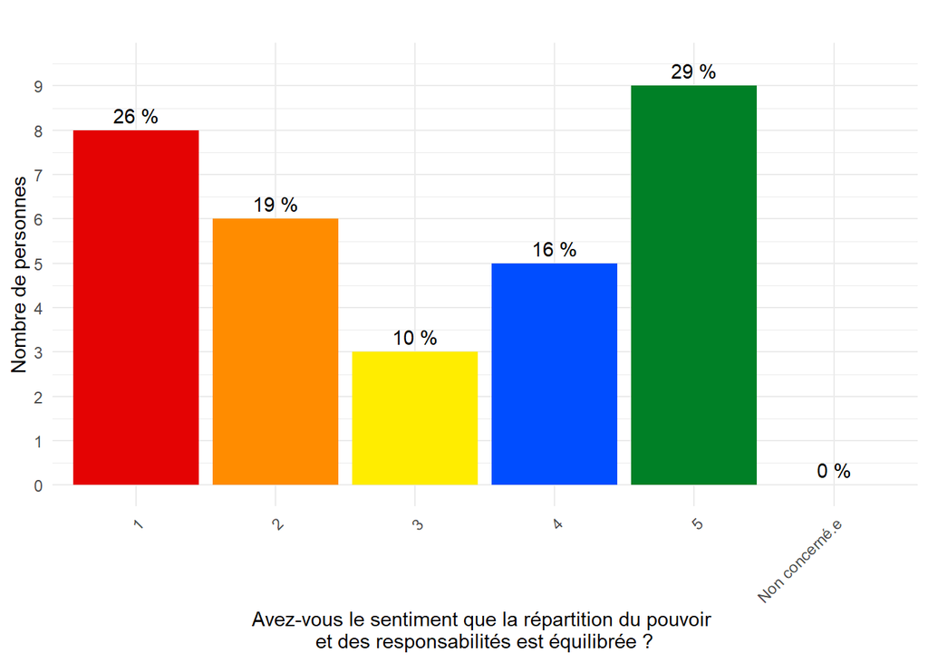